# Zooplankton Investigation

Author

Elizabeth Raphaels

## Loading Packages

```r
#install.packages('insight', repos=https://easystats.r-universe.dev')
library(tidyverse)
library(splines)
library(rnaturalearth)
library(rnaturalearthdata)
library(ggeffects)
library(insight)
library(lubridate)
library(patchwork)
library(ecoCopula)
library(ggrepel)
library(mvabund)
```

# Part 1: Patterns in Zooplankton Distribution from the Continuous Plankton Recorder (CPR)

## Reading in and Cleaning Data

I’m interested in using some data from the IMOS CPR sampling done around Australia and in the Southern Ocean to examine trends in zooplankton One data set - IMOS-ZooplanktonCPR.csv contains counts of zooplankton taxa from different samples. This IMOS-Zooplankton Abundance and Biomass Index (CPR) Derived Indices.csv contains derived data such as the Shannon’s diversity index of copepods in a sample or the Omnivore:Carnivore ratio of specifically copepods in a sample.

```r
#read in data
zoop  <- read_csv("IMOS_-_ZooplanktonCPR.csv")
zoop.index <- read.csv("IMOS_-_Zooplankton_Abundance_and_Biomass_Index_(CPR)-Derived_Indices.csv")

#store metadata as a new dataframe and remove it from zoop
meta.zoop <- zoop %>% select(1:17)

zoop <- zoop %>% select(17:last_col())
```

## Visualising Dominant Taxa

Examining the bar plot below - dominant groups sampled are Copepods, Cladocerans, and Appendicularians

```r
#take the mean abundance of each taxa and pivot the dataframe into a longer format
taxaMean <- zoop %>%
  summarise(across(.fns = mean)) %>%
  pivot_longer(cols = 1:33, names_to = "Taxa", values_to = "Mean_Abundance")
```

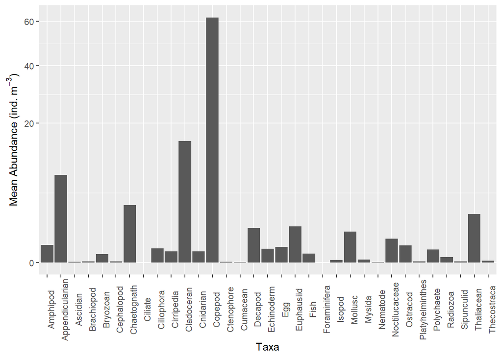

```r
ggplot(data = taxaMean, aes(x = Taxa, y = Mean_Abundance)) +
  geom_bar(stat = "identity") + # generate a bar plot
  theme(axis.text.x = element_text(angle = 90))+
  scale_y_sqrt()+
  ylab(bquote('Mean Abundance (ind.'~m^-3*')'))
```

## Simple Linear Model to Explain Variations in Abundance

Does zooplankton abundance vary with latitude? First trying a **simple linear model** with zooplankton abundance and latitude as the response and predictor variables, respectively.

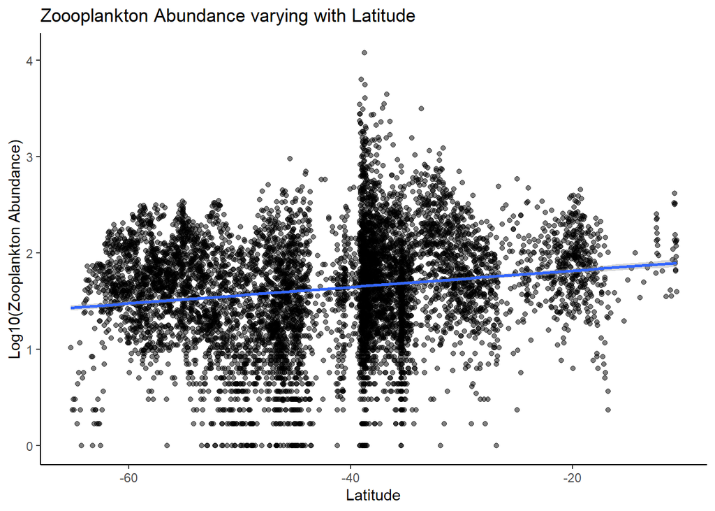

```r
#Altering the dataframe to best visualise a scatterplot with latitude vs. zooplankton abundance

  #Step 1. Calculate the mean count per taxa in each sample, while replacing NA's with zeros for now
zoop <- zoop %>%    mutate_all(~replace(., is.na(.), 0))%>%   rowwise() %>%    mutate(Total_Abund = sum(across()))

  #Step 2. Since I want to log the abundance values, I need to handle the 0 values in the dataset. I will add a small number, in this case, half the minimum value, to everything
min_val <- zoop %>%   select(Total_Abund) %>%   filter(Total_Abund>0)
min_val <- min(min_val$Total_Abund)/2

  #Step 3. make a new column in the zoop data frame representing the logged values of zooplankton abundance
zoop <- zoop %>%   mutate(zoopAbund = log10(Total_Abund+min_val))

  #Step 4. Merge the zooplankton counts back with the metadata dataset containing latitude information of the samples
full_data <- bind_cols(meta.zoop, zoop)

  #Step 5. Make a linear model of Abundance as a function of latitude
modelA <- lm(zoopAbund ~ Latitude, data=full_data)


  #Step 6. Make a scatterplot of the data and model
ggplot(data=full_data, aes(x=Latitude, y=zoopAbund))+
  geom_point(alpha=0.5)+   theme_classic()+
  ggtitle('Zoooplankton Abundance varying with Latitude')+
  ylab("Log10(Zooplankton Abundance)")+
  geom_smooth(method='lm')
```

```r
#Step 7. Is the relationship significant?
summary(modelA)
```

```
Call:
lm(formula = zoopAbund ~ Latitude, data = full_data)

Residuals:
     Min       1Q   Median       3Q      Max
-1.75704 -0.34652  0.03337  0.37467  2.42524

Coefficients:
             Estimate Std. Error t value Pr(>|t|)
(Intercept) 1.9856263  0.0253828   78.23   <2e-16 ***
Latitude    0.0085131  0.0005821   14.63   <2e-16 ***
---
Signif. codes:  0 '***' 0.001 '**' 0.01 '*' 0.05 '.' 0.1 ' ' 1

Residual standard error: 0.5588 on 7452 degrees of freedom
Multiple R-squared:  0.0279,    Adjusted R-squared:  0.02777
F-statistic: 213.9 on 1 and 7452 DF,  p-value: < 2.2e-16
```

The model indicates a significant positive relationship between zooplankton abundance and latitude for the CPR samples (p<2e-16, F=213.9). However, with an R-squared value of 0.0277, the model doesn’t explain the variation in the data well. It might be interesting if there are two different relationships between north and south of 42 degrees south latitude

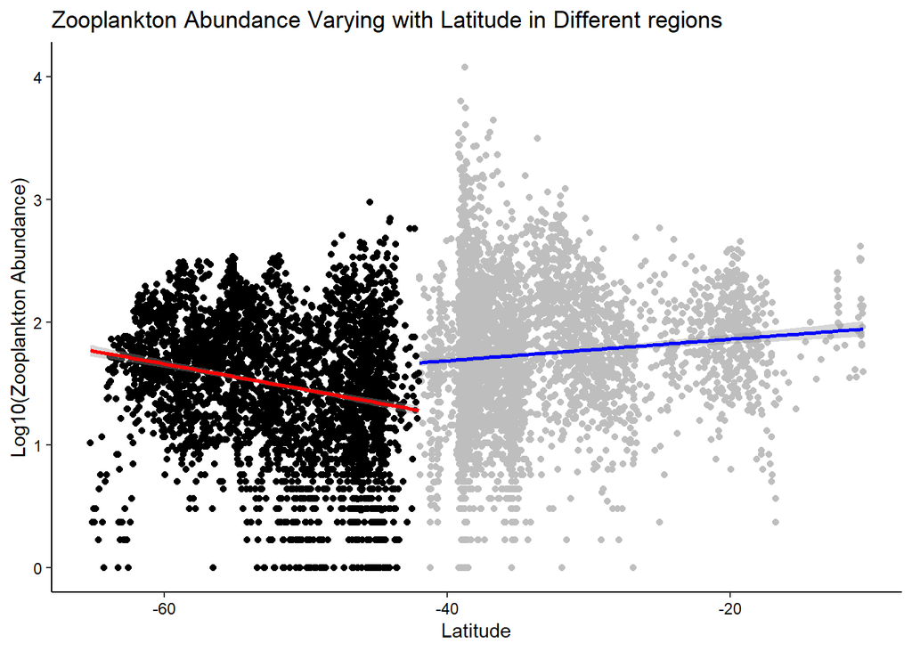

```r
#Step 1. Separate the dataset into sampling done north and south of 42 degrees south.
zoo_north <- full_data %>%   filter(Latitude > -42)
zoo_south <- full_data %>%   filter(Latitude< -42)

#Step 2. Linear models for the north and south datasets
modelS <- lm(zoopAbund ~ Latitude, data=zoo_south)
modelN <- lm(zoopAbund ~ Latitude, data=zoo_north)

#Step 3. Add separate models onto our scatterplot
ggplot(data = full_data, aes(x = Latitude, y = zoopAbund)) +
  geom_point(data = zoo_north, colour = "grey", shape = 16) +
  geom_point(data = zoo_south, colour = "black", shape = 16) +
  geom_smooth(data = zoo_south, method = "lm", colour='red') +
  geom_smooth(data = zoo_north, method = "lm", colour='blue') +
  theme_classic() +   ylab("Log10(Zooplankton Abundance)") +
  theme(axis.text = element_text(colour = "black")) +
  ggtitle('Zooplankton Abundance Varying with Latitude in Different regions')
```

We do see two different relationships in the two different regions. This suggests we may want to use a non-linear model to represent our data.

## Visualising Distribution of Data using Derived Indexed Dataset

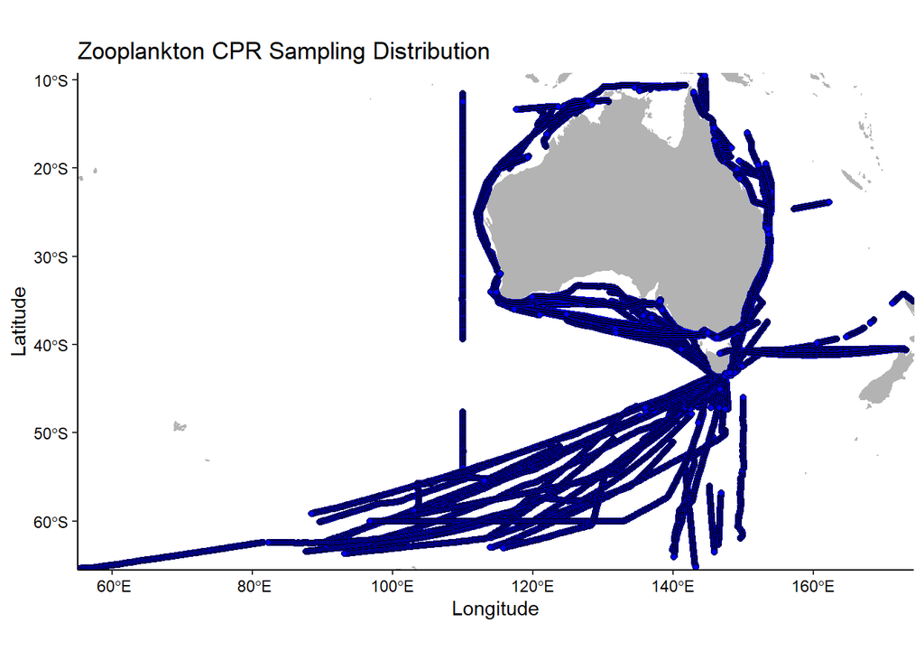

```r
#Create a map of our data

  #extract world map as a 'simple feature' from rnaturealearth package
world <- ne_countries(scale = "medium", returnclass = "sf")

  #add latitude and longitude ranges using the derived index dataset
min_Long <- min(zoop.index$Longitude)
max_Long <- max(zoop.index$Longitude)

min_Lat <- min(zoop.index$Latitude)
max_Lat <- max(zoop.index$Latitude)

  #Plot sampling data onto our world map
ggplot() +
  geom_sf(data = world, colour = "grey70", fill = "grey70") +
  geom_point(data = zoop.index, aes(x = Longitude, y = Latitude), size = 1.5, shape = 21, fill = "blue") +
  ggtitle('Zooplankton CPR Sampling Distribution')+
  scale_x_continuous(expand = c(0, 0), limits = c(min_Long, max_Long)) +
  scale_y_continuous(expand = c(0, 0), limits = c(min_Lat, max_Lat)) +
  theme_classic() +
  theme(axis.text = element_text(colour = "black"))
```

### Temporal, Seasonal, Diurnal Ranges of the Data

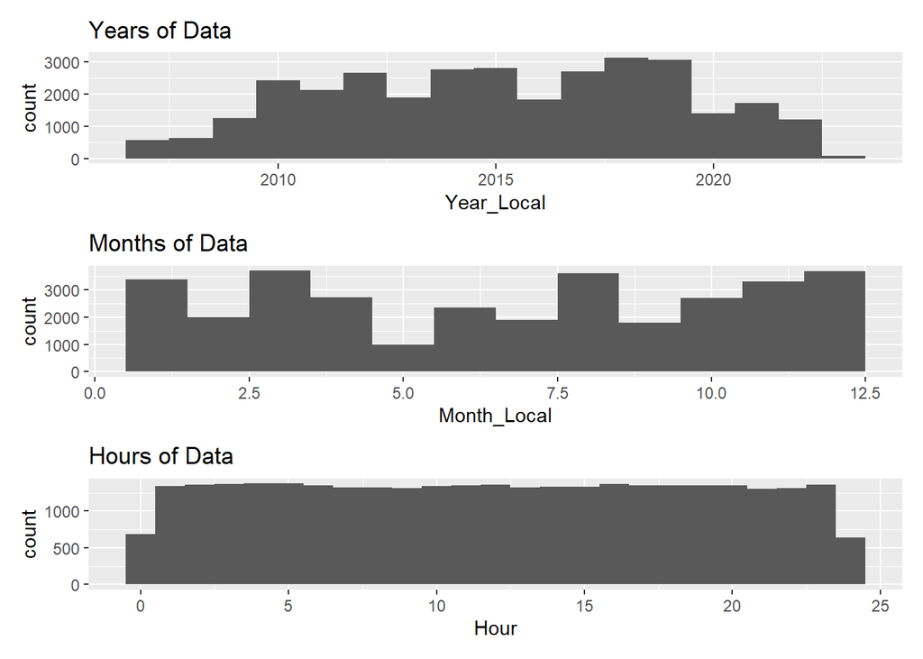

```r
#with lubridata package split the UTC time into DateTime
zoop.index <- zoop.index %>%
  mutate(DateTime = parse_date_time(SampleTime_UTC, 'ymd HMS'))# Tell R what format the date is in, and let it read it into the official format.

  #also count the decimal hour
zoop.index <- zoop.index %>%
  mutate(Hour = (hour(DateTime) + minute(DateTime) / 60)) # Calculate the decimal Hour

  #Create plots to patch together in oone image to examine data distribution over year, month, and hour
year <- ggplot(data = zoop.index, aes(x = Year_Local)) +
  geom_histogram(binwidth = 1)+
  ggtitle('Years of Data')

month <- ggplot(data = zoop.index, aes(x = Month_Local)) +
  geom_histogram(binwidth = 1)+
  ggtitle('Months of Data')

hour <- ggplot(data = zoop.index, aes(x = Hour)) +
  geom_histogram(binwidth = 1)+
  ggtitle('Hours of Data')

year/month/hour
```

Some trends we see - decrease in sampling during certain years, notably a decrease between 2019 and 2020 probably due to the COVID19 Pandemic. Also seems to be an increase in sampling in the summer months.

## Copepod Diversity

```r
#read in the matched environmental data set
envmt <- read_csv("https://raw.githubusercontent.com/HaydenSchilling/Example_code_and_data/master/IMOS_-_AusCPR%23_Zooplankton_Abundance-Derived_CPR_Indices.csv", na="-999")

#testing if richness and SST correlate with Pearson's
corr_out <- cor.test(envmt$SST_C, envmt$ShannonCopepodDiversity)
rsquar <- as.numeric(corr_out$estimate) ^ 2
corr_out
```

```
    Pearson's product-moment correlation

data:  envmt$SST_C and envmt$ShannonCopepodDiversity
t = 52.83, df = 6078, p-value < 2.2e-16
alternative hypothesis: true correlation is not equal to 0
95 percent confidence interval:
 0.5435027 0.5779625
sample estimates:
      cor
0.5609756
```

```r
rsquar
```

```
[1] 0.3146936
```

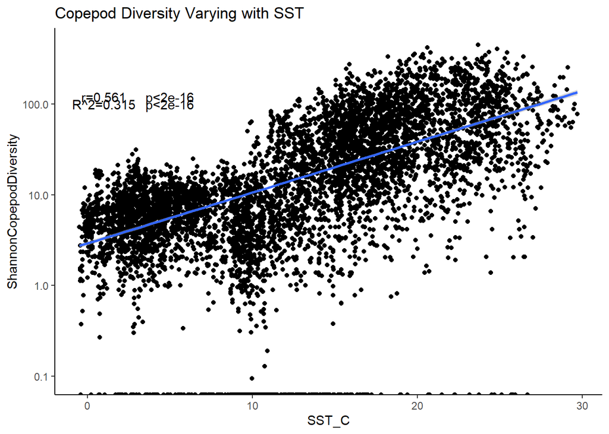

```r
#plot the Shannon's Diversity Index for Copepods vs. SST
ggplot(data = envmt, aes(x = SST_C, y = ShannonCopepodDiversity)) +
  geom_point() +
  scale_y_log10()+
  theme_classic()+
  geom_smooth(method='lm')+
  ggtitle('Copepod Diversity Varying with SST')+
  annotate(geom="text", x=1, y=100, label="R^2=0.315" )+ #adds linear model R-squared value
  annotate(geom='text', x=5, y=100, label='p<2e-16') + #adds linear model p value
  annotate(geom='text', x=1, y=120, label='r=0.561')+ #adds correlation coefficient
  annotate(geom='text', x=5, y=120, label='p<2e-16') #adds correlation test R-squared value
```

## Feeding Strategies

Using the same matched environmental dataset, does the feeding strategy of copepods (carnivores vs. herbivores) change with latitude? From the column, HerbivoreCarnivoreCopepodRatio- A ratio of 1 indicates that only herbivorous copepods were present in a sample, and a ratio of 0 represents a sample with only carnivores.

Results: From the violin plot, we see that for all temperatures, the ratio of herbivores to copepods is greater than 0.75. From 16C upwards, the ratio starts to decrease and more carnivorous individuals were found in the samples. In summation, as you increase in SST and decrease Latitude, there are more carnivorous copepods present, but on average there are more herbivores than carnivores in a sample.

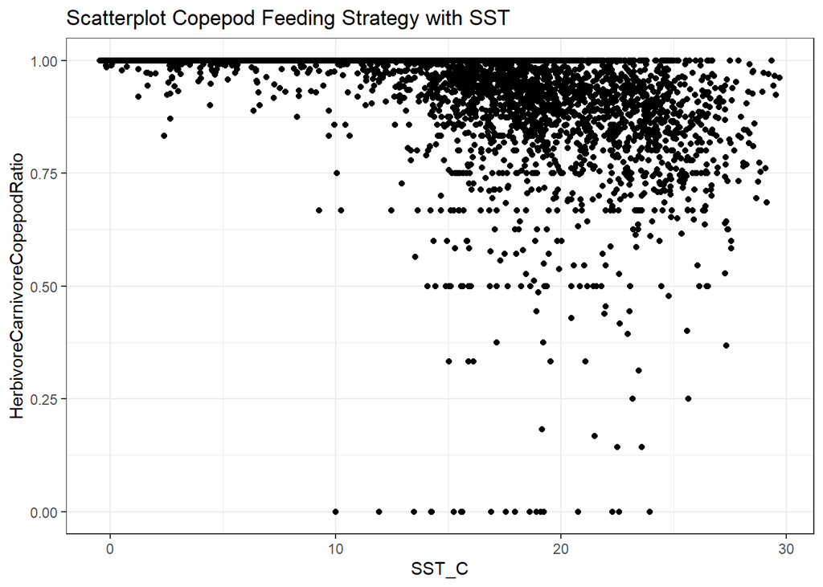

```r
#Creating a scatterplot
ggplot(data = envmt, aes(x = SST_C, y = HerbivoreCarnivoreCopepodRatio)) +
  geom_point()+
  ggtitle('Scatterplot Copepod Feeding Strategy with SST')+
  theme_bw()
```

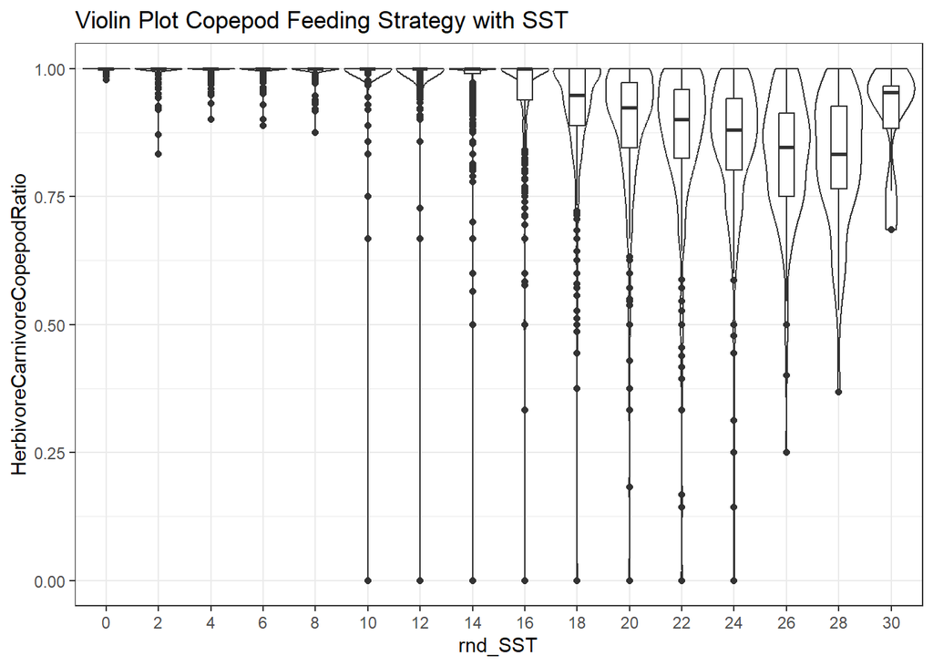

```r
#Creating a violin plot

  #Putting SST into bins of 2 degrees C.
envmt <- envmt %>%
  mutate(rnd_SST = as.factor(2 * round(envmt$SST_C/ 2)))%>%
    drop_na(rnd_SST)

ggplot(data = envmt, aes(x = rnd_SST, y = HerbivoreCarnivoreCopepodRatio)) +
  geom_violin(scale = "width") +
  geom_boxplot(width = 0.3) +
  theme_bw()+
  ggtitle('Violin Plot Copepod Feeding Strategy with SST')
```

Now why may we see this pattern?

Prey size and availability may impact copepod feeding strategy. Previous studies describe copepod body size decreasing with temperature and microzooplankton being more abundant at high latitudes (Brun et al. 2016; Prowe et al. 2018). Since zooplankton body size has been found to be associated with prey size, (Brun et al. 2016) smaller copepods at the poles may be more likely to feed on small phytoplankton making them herbivores, while larger individuals in the sub-tropics/tropics can eat larger prey items, like other zooplankton, and adopt a carnivorous feeding strategy.

If there are more larger prey items towards the equator, then we would see more copepods that have adapted to feed on these, seeing more carnivores towards the equator and more herbivores near the poles.

Why is this important: understanding feeding strategy - important to fisheries, biogeochemical cycles (C uptake by phytoplantkon), trophic transfer

Brun, P., Payne, M. R., & Kiørboe, T. (2016). Trait biogeography of marine copepods–an analysis across scales. *Ecology Letters*, *19*(12), 1403-1413.

Prowe, A. F., Visser, A. W., Andersen, K. H., Chiba, S., & Kiørboe, T. (2019). Biogeography of zooplankton feeding strategy. *Limnology and Oceanography*, *64*(2), 661-678.

# Part 2: Patterns in Zooplankton from Australia National Reference Stations

Overall, I’m curious if Australian National Reference Stations have distinctive larval fish communities from their zooplankton sampling.

1. Are there different communities at the different stations? (i.e., can we sample fewer stations?)
2. If there are different communities, what environmental variables might structure these communities?

## Reading in and Cleaning our Data

```r
#data file subsetted from AODN
rm(list = ls())

data <- read_csv("https://raw.githubusercontent.com/HaydenSchilling/Example_code_and_data/master/IMOS%20Larval%20Fish%20TAMS.csv")

#creating a subsetted data frame that only has columns for taxa/species counts, ensure every column has numerical data, and remove some taxa that were never present in the samples and do not have any counts

taxa <- data %>%
  select(Acanthuridae_37437900:Phycidae_Gaidropsarus.spp_37226902)%>%
  mutate_all(as.numeric)%>%
  select_if(function(col) sum(col, na.rm=TRUE) !=0 )  #will return the sum of each column and select the column if the sum does not equal 0
```

## Map of Data

Which National Reference Stations are we looking at samples from?

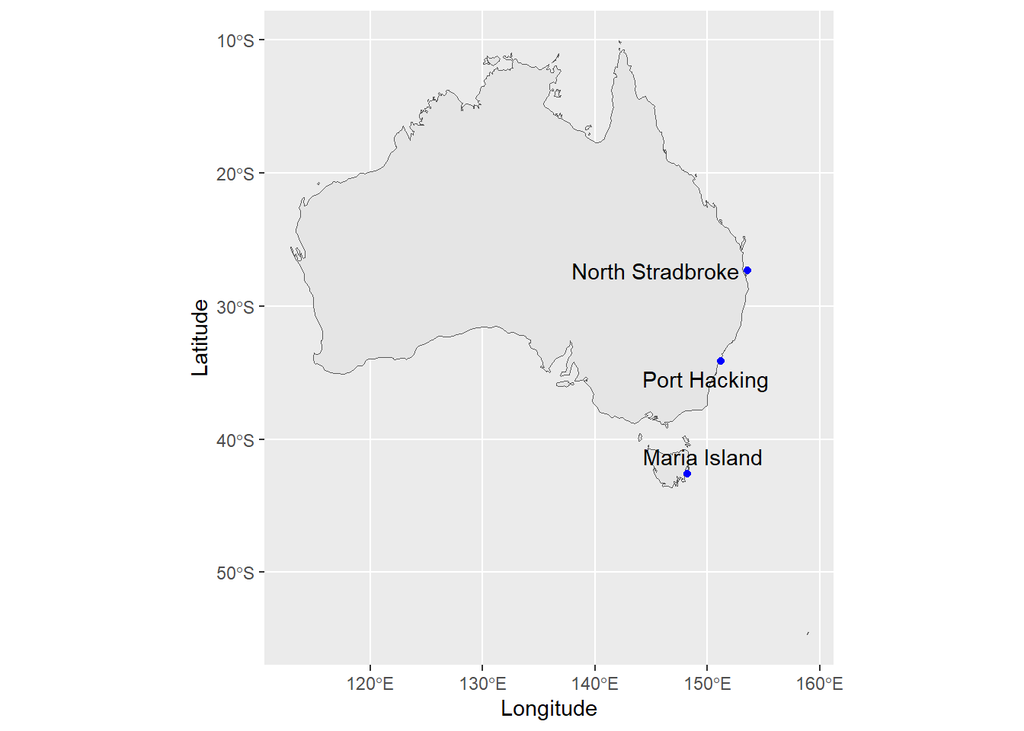

```r
#creating a simple figure map of Australia
Aus <- ne_countries(country = "Australia", scale = "medium", returnclass = "sf")

#dataframe with distinct stations
dat_plot <- data %>% distinct(Station, .keep_all = TRUE)

#plotting the stations of our Australia map
ggplot(data = dat_plot, aes(x = Longitude, y = Latitude)) +
  geom_sf(data = Aus, inherit.aes = FALSE) +
  geom_point(colour = "blue") +
  geom_text_repel(aes(label = Station))
```

## Examining mean and variance

Abundances of several species across sites and measures of abiotic variables at sites can be dealt with using multivariate statistical approaches to answer ecological questions.

Examining our data set further, the data does not have equal variance between species’ counts. Species with very high mean abundances also have greater variance as shown from our mean-variance plot. This means we shouldn’t use distance based approaches for a multivariate analysis. Instead we can use a model based approach using multivariate generalised linear models to investigate larval fish communities between sampling stations.

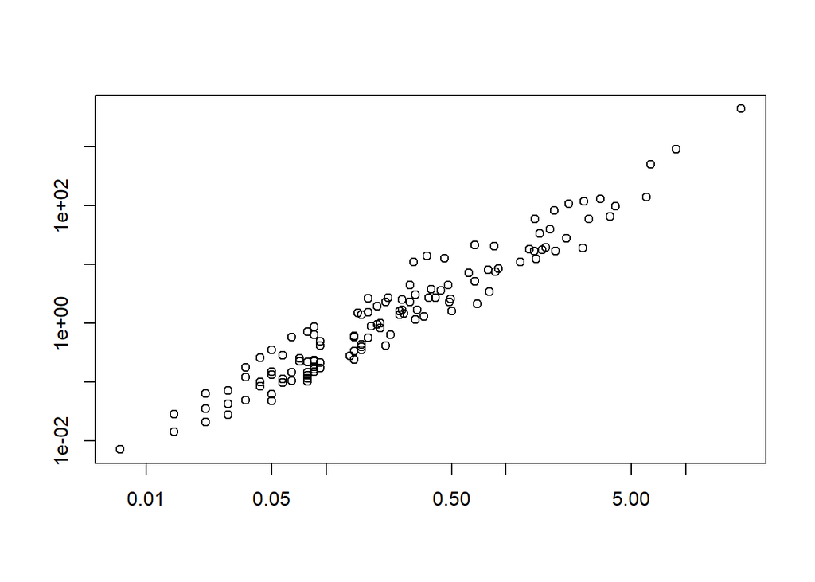

```r
#We can visualise the mean-variance relationship in our data by plotting the mean and variance of each species with the help of the mvabund library.

# use the dataframe, taxa, with only fish counts, to create a Multivariate Abundance Data Object
fishy <- mvabund(taxa)

#create a mean-variance plot for our multivariate abundance data
meanvar.plot(fishy)
```

## Modelling and Visualising Larval Fish Communities between stations

We can visualise how similar Stations are based on their larval fish communities with a Model-Based Ordination plot using cord() to transform our multivariate abundance data. Running an ANOVA on our generalised linear model will determine if the larval fish communities were significantly different from station to station.

Examining the plot below we determined that the communities were different from station to station based on the clustering of samples at each station. The p-value of the ANOVA for our model was 0.048, assuming a critical value of a=0.05, we can say that YES - the larval communities are significantly different around Australia. At least for these 3 stations on the East Coast.

```r
#fit a generalised linear model to larval fish abundance vs. NRS
model1 <- manyglm(fishy ~ Station, data=data, offset=log(Volume_m3))


#make a null model for plotting
mod1b <- manyglm(fishy~1, offset=log(data$Volume_m3))

#usinc cord() from ecoCopula library allows us to visualise how samples(sites) and variables(taxa) are located along several latent variables(an unobserved envmtal gradient)
fish_lv <- cord(mod1b)

#extract values for filtering and plotting
Lv_scores <- as.data.frame(fish_lv$scores)
Sp_loadings <- as.data.frame(fish_lv$loadings)
Sp_loadings$Length <- sqrt(Sp_loadings$Factor1 ^ 2 + Sp_loadings$Factor2 ^ 2) # calculate vector length (Pythagoras' theorem)
Sp_loadings$Species <- colnames(fishy)
Sp_loadings_10 <- Sp_loadings %>% slice_max(order_by = Length, n = 10) # 10 longest vectors

#running an ANOVA to see if our generalised linear model is significant
anova(model1, nBoot = 20)
```

```
Time elapsed: 0 hr 0 min 15 sec
```

```
Analysis of Deviance Table

Model: fishy ~ Station

Multivariate test:
            Res.Df Df.diff  Dev Pr(>Dev)
(Intercept)    139
Station        137       2 2473    0.048 *
---
Signif. codes:  0 '***' 0.001 '**' 0.01 '*' 0.05 '.' 0.1 ' ' 1
Arguments:
 Test statistics calculated assuming uncorrelated response (for faster computation)
 P-value calculated using 20 iterations via PIT-trap resampling.
```

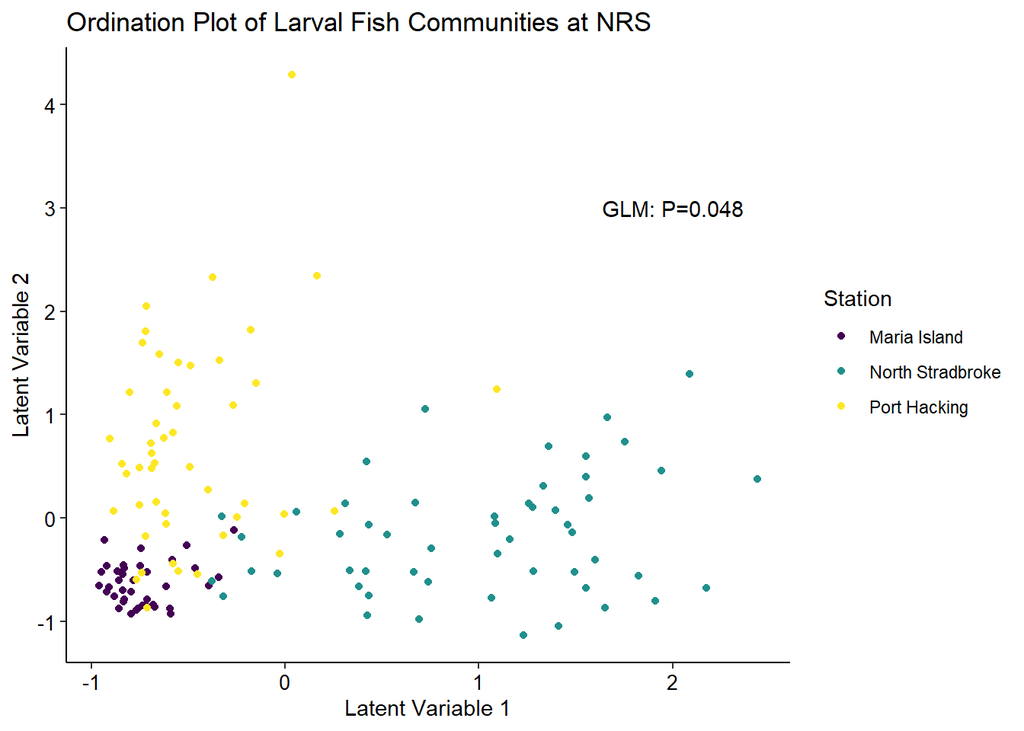

```r
#plotting
Station <- ggplot() +
  geom_point(data = Lv_scores, aes(x = Factor1, y = Factor2, colour = data$Station)) +
  theme_classic() +
  scale_colour_viridis_d(name = "Station") +
  xlab("Latent Variable 1") +
  ylab("Latent Variable 2") +
  ggtitle("Ordination Plot of Larval Fish Communities at NRS")+
  theme(axis.text = element_text(colour = "black", size = 10))+
  annotate('text', x=2, y=3, label='GLM: P=0.048')
Station
```

### Temperature as a Covariate

We can colour sample points on our plot according to temperature rather than Station, to see how the larval fish community varies by Station with temperature as a co-variate.

From clustering on the ordination plot, mirroring clustering of stations, and an ANOVA, temperature is significantly related to the distinct larval fish communities at the different National Reference Stations (p<0.048).

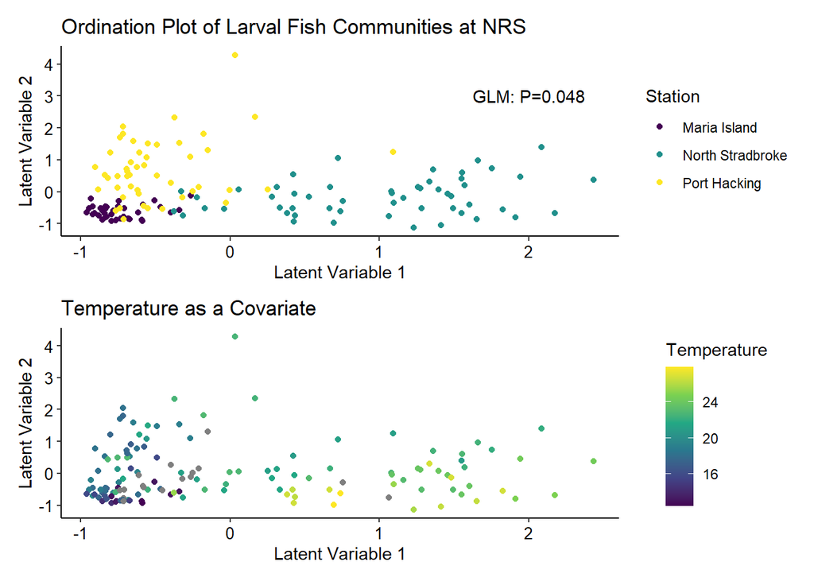

```r
#Colouring our ordination plot samples by temperature
Temp_Station <- ggplot() +
  geom_point(data = Lv_scores, aes(x = Factor1, y = Factor2, colour = data$CTD_SST_C)) +
  theme_classic() +
  scale_colour_viridis_c('Temperature') +
  xlab("Latent Variable 1") +
  ylab("Latent Variable 2") +
  ggtitle("Temperature as a Covariate")+
  theme(axis.text = element_text(colour = "black", size = 10))

Station / Temp_Station
```

```r
#is temperature significantly related?
modelT <- manyglm(fishy ~ CTD_SST_C, data = data, offset = log(Volume_m3))

anova(modelT, nBoot = 20)
```

```
Time elapsed: 0 hr 0 min 16 sec
```

```
Analysis of Deviance Table

Model: fishy ~ CTD_SST_C

Multivariate test:
            Res.Df Df.diff  Dev Pr(>Dev)
(Intercept)    123
CTD_SST_C      122       1 1175    0.048 *
---
Signif. codes:  0 '***' 0.001 '**' 0.01 '*' 0.05 '.' 0.1 ' ' 1
Arguments:
 Test statistics calculated assuming uncorrelated response (for faster computation)
 P-value calculated using 20 iterations via PIT-trap resampling.
```

### Which Taxa contribute the most to the differences between sites?

Using outputs from an ANOVA, we can calculate a percentage of likelihood ratio to see which taxa groups are driving the separation of sites. Species from the groups Lutjanidae, Carangidae, and Gobiidae seem to be the top 3 drivers of distinct communities between the stations. Looking at the ordination plot, Lutijanidae and Carangidae are causing the distinction of North Stradborke, and Port Hacking, communities, respectively.

```r
#going back to our Station model
out <- anova(model1, nBoot = 20, p.uni = "adjusted") # conduct anova
```

```
Time elapsed: 0 hr 0 min 18 sec
```

```r
out2 <- as.data.frame(out$uni.test)

out2 <- out2 %>% t() %>% as.data.frame()

sum_of_likelihood <- sum(out2$Station)

out2 <- out2 %>%
  mutate(Taxa = row.names(out2),
         Percent_Contribution = Station / sum_of_likelihood * 100) %>%
  arrange(desc(Percent_Contribution)) # sort to have the most important at the top

## Check the percentages
sum(out2$Percent_Contribution)
```

```
[1] 100
```

```r
out2[1:3, 2:4]
```

```
                                              Station
Lutjanidae_37346932                          96.78759
Carangidae_Trachurus.novaezelandiae_37337003 89.56044
Gobiidae_37428000                            76.50326
                                                                                     Taxa
Lutjanidae_37346932                                                   Lutjanidae_37346932
Carangidae_Trachurus.novaezelandiae_37337003 Carangidae_Trachurus.novaezelandiae_37337003
Gobiidae_37428000                                                       Gobiidae_37428000
                                             Percent_Contribution
Lutjanidae_37346932                                      3.913565
Carangidae_Trachurus.novaezelandiae_37337003             3.621338
Gobiidae_37428000                                        3.093377
```

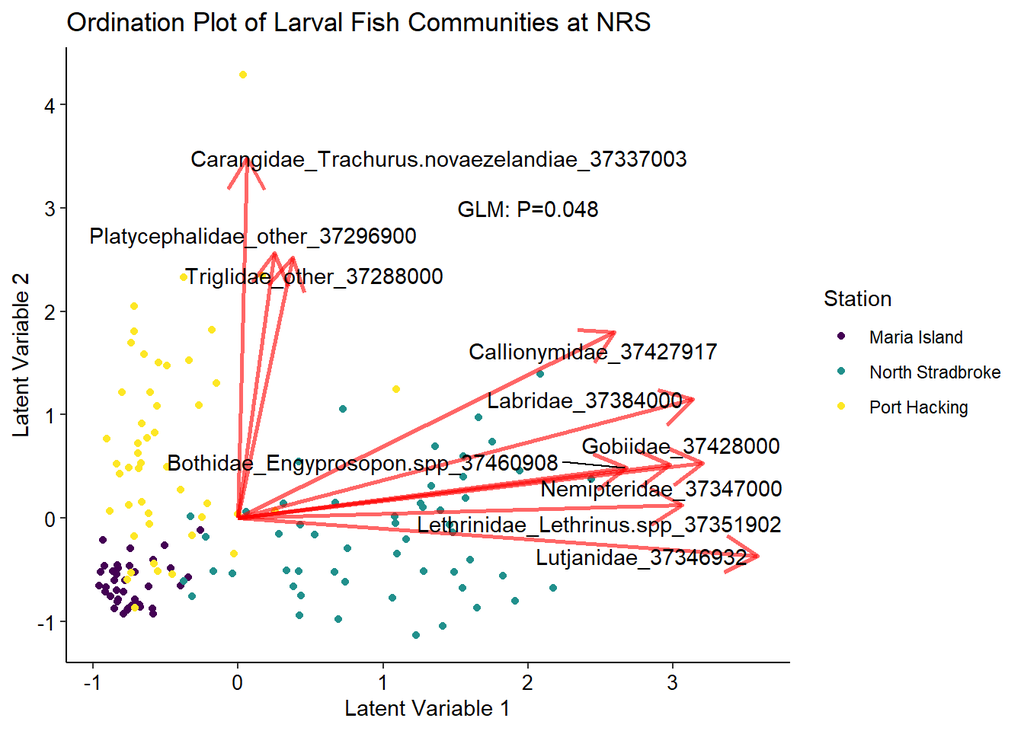

```r
#plot species vectors onto the ordination plot
Station_Species <- ggplot() +
  geom_point(data = Lv_scores, aes(x = Factor1, y = Factor2, colour = data$Station)) +
  theme_classic() +
  scale_colour_viridis_d(name = "Station") +
  xlab("Latent Variable 1") +
  ylab("Latent Variable 2") +
  ggtitle("Ordination Plot of Larval Fish Communities at NRS")+
  theme(axis.text = element_text(colour = "black", size = 10))+
  annotate('text', x=2, y=3, label='GLM: P=0.048')+
  annotate("segment", x = rep(0, 10), xend = Sp_loadings_10$Factor1 * 5, y = rep(0, 10), yend = Sp_loadings_10$Factor2 * 5, colour = "red", linewidth = 1, alpha = 0.6, arrow = arrow()) +
  geom_text_repel(aes(x = Sp_loadings_10$Factor1 * 5, y = Sp_loadings_10$Factor2 * 5, label = Sp_loadings_10$Species))

Station_Species
```